# cv6.R

Marek

2023-03-30

```r
library('latexpdf')
```

# Dvojvyberove testy pre parametre normalneho rozdelenia

Dvojvyberove testy su - parove pre zavisle merania, bolo - neparove pre nezavisle merania Testujeme hypotezu o rovnosti strednych hodnot, testy treba vybrat podla toho, ci sa disperzie rovnaju alebo nerovnaju. - test, ak disperzie sa rovnaju - test, ak sa disperzie nerovnaju Priklad 1 Dva druhy plastov (plastove okna) sme vystavili slnecnemu ziareniu po dobu pol roka. Vysledky (odolnosti voci ziareniu v dnoch) sme zaznamenali. Na hladine vyznamnosti $\alpha=0.05$. Testujte hypotezu o rovnakej odolnosti voci slnecnemu ziareniu.

```r
prvy <- c(85, 87, 92, 80, 84, 86)
druhy <- c(89, 89, 90, 84, 92)
```

Najprv grafy

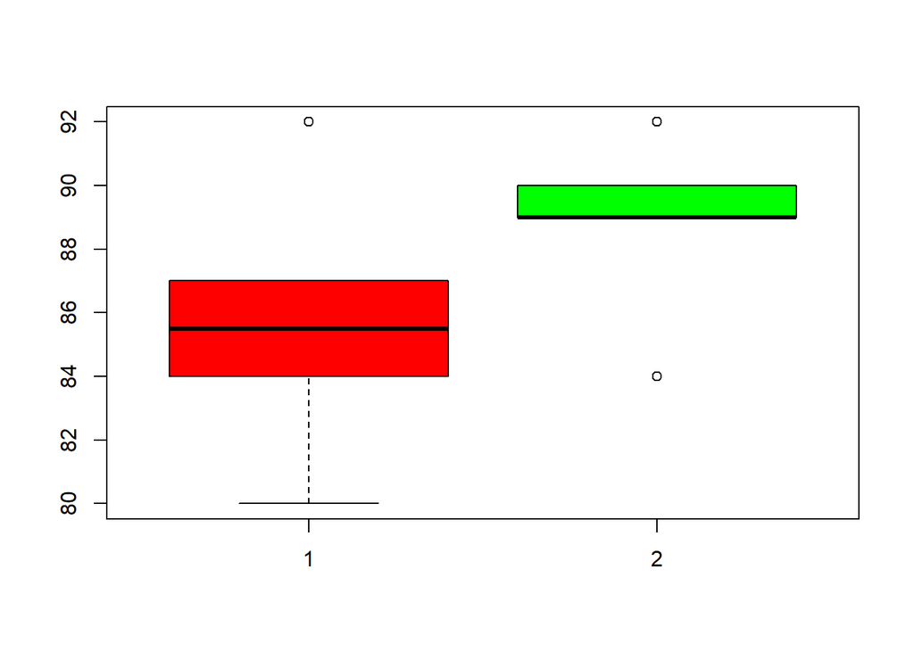

```r
boxplot(prvy, druhy, col = c('red', 'green'))
```

Test o rovnosti disperzii, pouzijeme Fisher Ratio test

```r
var.test(prvy, druhy)
```

```
##
##  F test to compare two variances
##
## data:  prvy and druhy
## F = 1.7778, num df = 5, denom df = 4, p-value = 0.5971
## alternative hypothesis: true ratio of variances is not equal to 1
## 95 percent confidence interval:
##   0.1898428 13.1340191
## sample estimates:
## ratio of variances
##           1.777778
```

```r
var.test(prvy, druhy)$p.value
```

```
## [1] 0.5971242
```

Kedze P hodnota = 0.59 > 0.05 nezamietam hypotezu o rovnosti disperzii. Vyberieme spravny test rovnosti strednych hodnot

```r
t.test(prvy, druhy, paired = F, var.equal = T)
```

```
##
##  Two Sample t-test
##
## data:  prvy and druhy
## t = -1.466, df = 9, p-value = 0.1767
## alternative hypothesis: true difference in means is not equal to 0
## 95 percent confidence interval:
##  -7.968424  1.701757
## sample estimates:
## mean of x mean of y
##  85.66667  88.80000
```

```r
t.test(prvy, druhy, paired = F, var.equal = T)$p.value
```

```
## [1] 0.1767033
```

P hodnota = 0.17 > 0.05, nezamietam hypotezu o rovnosti strednych hodnot, odolnost voci ziareniu je rovnaka.

```r
#####################################################
```

Priklad 2 - ked sa disperzie nebudu rovnat Firma odobera ochranne pracovne prostriedky od dvoch dodavatelov AA, BB. Zaznamenali sme dlzky dodavok na hladine vyznamnosti $\alpha=0.05$ Testujte hypotezu o tom, ze dlzky dodavok su rovnake

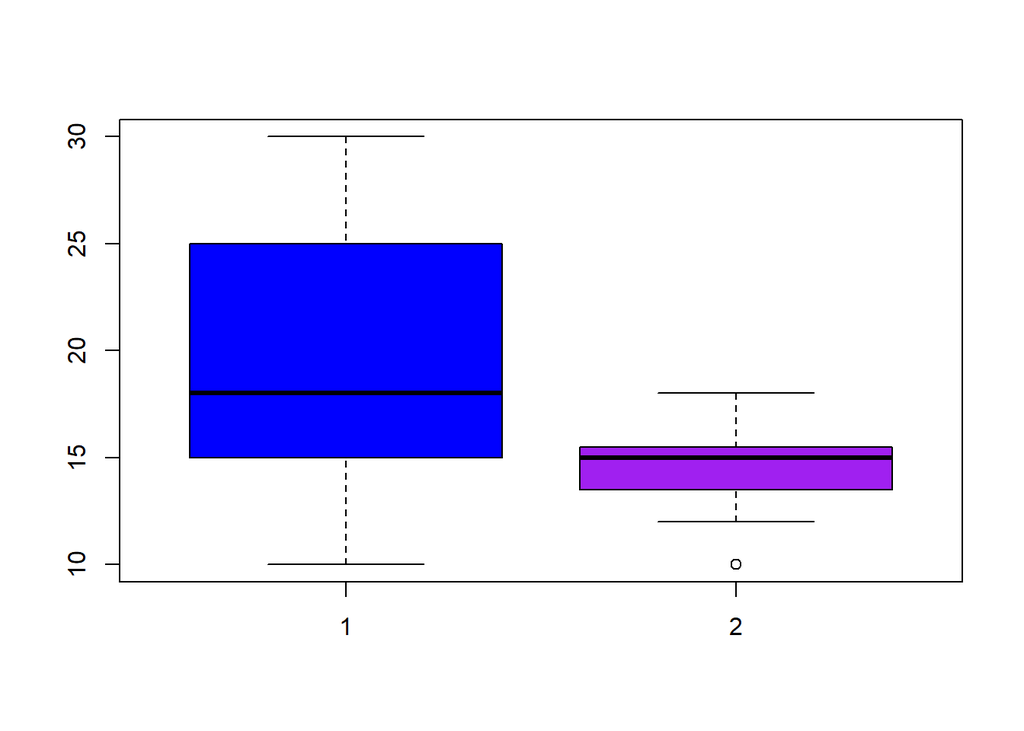

```r
aa <- c(10, 12, 15, 25, 18, 20, 15, 25, 30)
bb <- c(15, 15, 18, 10, 16, 12, 15)
boxplot(aa, bb, col = c('blue', 'purple'))
```

```r
var.test(aa, bb)$p.value
```

```
## [1] 0.0359276
```

Phodnota - 0.03 < 0.05, zamietam hypotezu o rovnosti disperzii Teraz test pre rovnost strednych hodnot

```r
t.test(aa, bb, paired = F, var.equal = F)$p.value
```

```
## [1] 0.09483095
```

phodnota = 0.09 > 0.05, nezamietam hypotezu o rovnosti strednych hodnot, dlzky dodavok su rovnake # ANOVA Analysis of Variance Testujeme hypotezu o rovnosti strednych hodnot viac ako dvoch vyberov.
$$H_0\quad \mu_1 = \mu_2 = .... = \mu_I$$
alternativa je aspon jedna dvojica sa nerovna Jednofaktorova analyza rozptylu (One Way ANOVA) Datovy subor sa rozlozi do tried podla nejakeho faktora, triedny faktor $\alpha_i$, mame napr. datovy subor mesacnych prijmov 50 respondentov, rozdelime mesacne prijmy podla faktora typ vzdelania, 1-svs, 2-sos, 3-vs Testujeme potom hypotezu o nulovosti triedneho faktora, cize triedny faktor nema vplyv na merania ANOVA ma silne predpoklady - normalita dat v triedach (Shapiro Wilk test) - rovnost disperzii v triedach (Bartlettov test) Ak podmienky nie su splnene, tak musime testovat neparametrickym testom (Kruskall Wallis)

```r
library(readxl)
library(RColorBrewer)
library(vioplot)
library(ggplot2)
library(ggpubr)
```

datovy subor dataE obsahuje, okrem ineho, data mesacny prijem a informaciu o vzdelani respondenta (triedny faktor-vzdelanie, tri urovne). Na hladine vyznamnosti $\alpha = 0.05$ testujte hypotezu, ze faktor vzdelanie je nulovy a teda nema vplyv na vysku prijmu

```r
data <- read_xlsx('..\\data\\dataE.xlsx')
data
```

```
## # A tibble: 50 × 13
##    respo…¹ pohla…²   vek vzdel…³  stav fajciar praca  clen mprij mstrava rdovo…⁴
##      <dbl> <chr>   <dbl>   <dbl> <dbl>   <dbl> <dbl> <dbl> <dbl>   <dbl>   <dbl>
##  1       1 m          28       3     1       0     2     5  1500     250   10000
##  2       2 m          22       2     1       0     1     4   900     200     350
##  3       3 m          50       1     2       0     2     4   975     350     300
##  4       4 z          39       2     2       0     3     5  1200     400     500
##  5       5 z          53       3     2       0     1     5  1800     400   15000
##  6       6 z          55       1     3       0     3     2   825     200     200
##  7       7 m          50       3     2       0     3     3  1350     350     900
##  8       8 z          39       1     2       1     3     4   675     250     200
##  9       9 z          57       2     2       0     1     2  1050     300     250
## 10      10 z          45       2     2       0     2     5  1125     320     450
## # … with 40 more rows, 2 more variables: pocit <dbl>, invest <dbl>, and
## #   abbreviated variable names ¹respondent, ²pohlavie, ³vzdelanie, ⁴rdovolenka
```

najprv graficka analyza

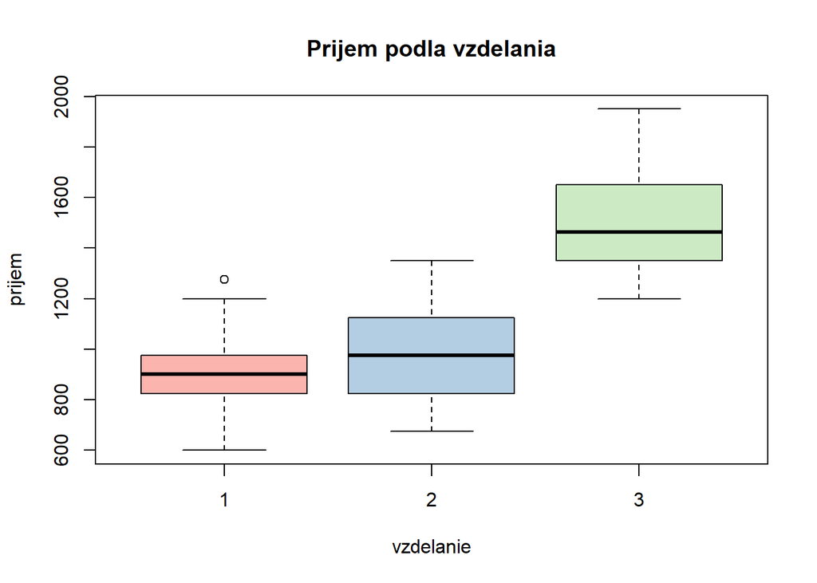

```r
boxplot(data$mprij~data$vzdelanie, col = brewer.pal(3, 'Pastel1'),
        main = 'Prijem podla vzdelania', xlab = 'vzdelanie',
        ylab = 'prijem')
```

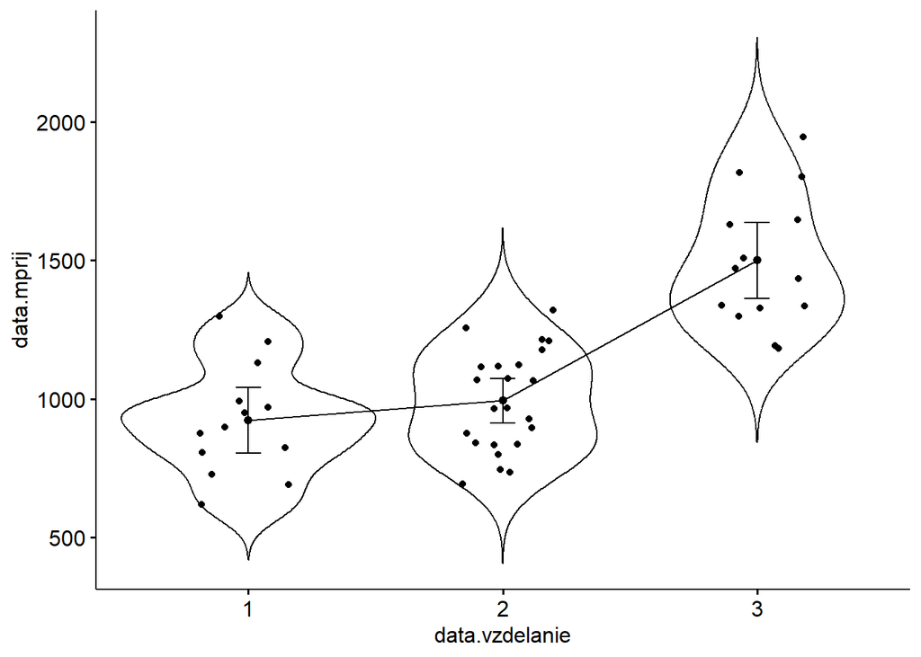

```r
pomoc <- data.frame(data$vzdelanie, data$mprij)
ggline(pomoc, x = 'data.vzdelanie', y = 'data.mprij',
       add = c('mean_ci', 'jitter', 'violin'))
```

Overime podmienky ANOVA Normalita dat v triedach

```r
tapply(data$mprij, data$vzdelanie, shapiro.test)
```

```
## $`1`
##
##  Shapiro-Wilk normality test
##
## data:  X[[i]]
## W = 0.97235, p-value = 0.9206
##
##
## $`2`
##
##  Shapiro-Wilk normality test
##
## data:  X[[i]]
## W = 0.96399, p-value = 0.5484
##
##
## $`3`
##
##  Shapiro-Wilk normality test
##
## data:  X[[i]]
## W = 0.93296, p-value = 0.3356
```

Nulova hypoteza je, ze data su normalne rozdelene P hodnoty pre kazdu triedu su > 0.05, teda nezamietam H0, data v triedach su normalne rozdelene Rovnost disperzii v triedach

```r
bartlett.test(data$mprij~data$vzdelanie)
```

```
##
##  Bartlett test of homogeneity of variances
##
## data:  data$mprij by data$vzdelanie
## Bartlett's K-squared = 1.0291, df = 2, p-value = 0.5978
```

H0 je, ze rovnost disperzii P hodnota > 0.05, nezamietam H0, disperzie v triedach su rovnake Pred vypoctom musime este faktorizovat vzdelanie

```r
vzdelanie <- factor(data$vzdelanie)
an1 <- aov(data$mprij~vzdelanie)
an1
```

```
## Call:
##    aov(formula = data$mprij ~ vzdelanie)
##
## Terms:
##                 vzdelanie Residuals
## Sum of Squares    2887290   1953023
## Deg. of Freedom         2        47
##
## Residual standard error: 203.8472
## Estimated effects may be unbalanced
```

```r
summary(an1)
```

```
##             Df  Sum Sq Mean Sq F value   Pr(>F)
## vzdelanie    2 2887290 1443645   34.74 5.46e-10 ***
## Residuals   47 1953023   41554
## ---
## Signif. codes:  0 '***' 0.001 '**' 0.01 '*' 0.05 '.' 0.1 ' ' 1
```

P hodnota < 0.05 zamietam hypotezu o nulovosti faktora vzdelanie, faktor je statisticky vyznamny a ma vplyv na mesacny prijem.. Nasleduju post testy, ktorymi urcime odlisnosti pre kazde dve triedy, Tukey, Scheffe post test

```r
TukeyHSD(an1)
```

```
##   Tukey multiple comparisons of means
##     95% family-wise confidence level
##
## Fit: aov(formula = data$mprij ~ vzdelanie)
##
## $vzdelanie
##          diff       lwr      upr     p adj
## 2-1  71.48829 -99.69349 242.6701 0.5738796
## 3-1 576.92308 386.90799 766.9382 0.0000000
## 3-2 505.43478 338.20454 672.6650 0.0000000
```

trieda 1, 2 - phodnota > 0.05, nezamietam hypotezu o rovnosti strednych hodnot, nie su odlisne trueda 1, 3 a 2, 3 Phodnota < 0.05, zamietam hypotezu o rovnosti strednych hodnot, triedy su odlisne

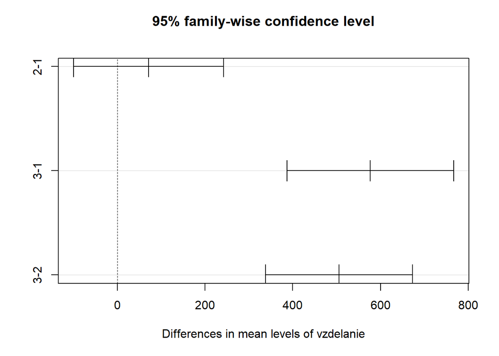

```r
plot(TukeyHSD(an1))
```

```r
library(DescTools)
ScheffeTest(an1)
```

```
##
##   Posthoc multiple comparisons of means: Scheffe Test
##     95% family-wise confidence level
##
## $vzdelanie
##          diff    lwr.ci   upr.ci    pval
## 2-1  71.48829 -107.3146 250.2912  0.6033
## 3-1 576.92308  378.4484 775.3978 1.6e-08 ***
## 3-2 505.43478  330.7593 680.1102 1.8e-08 ***
##
## ---
## Signif. codes:  0 '***' 0.001 '**' 0.01 '*' 0.05 '.' 0.1 ' ' 1
```

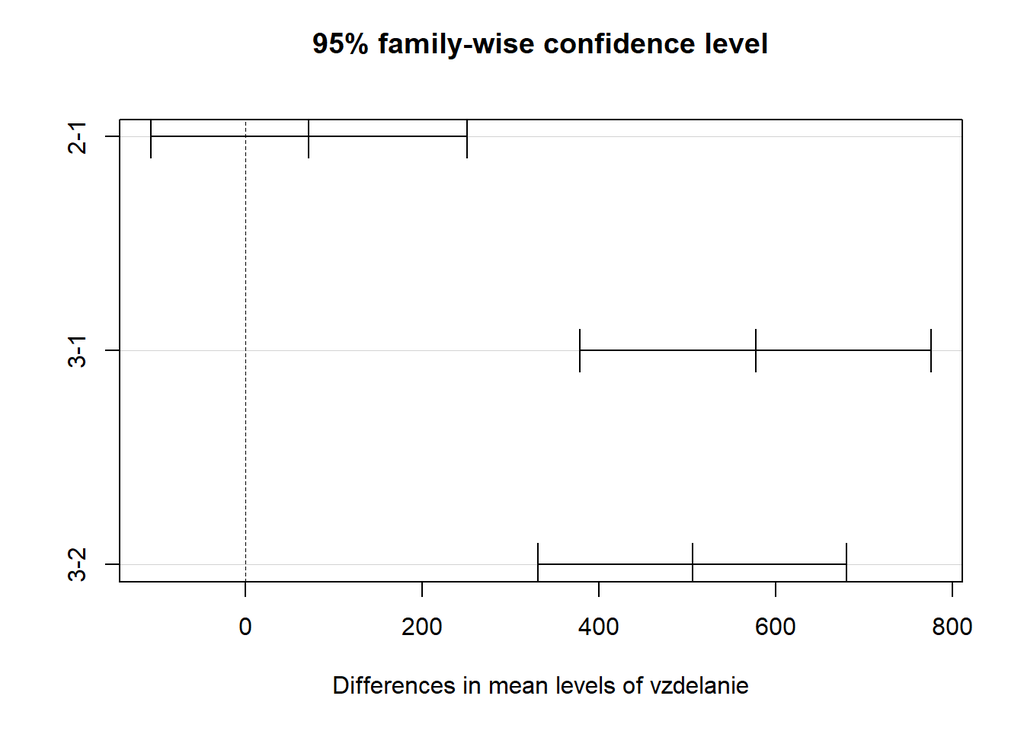

```r
plot(ScheffeTest(an1))
```

```r
#############################################
```

# Dvojfaktorova analyza rozptylu

Data sa rozdeluju do tried podla dvoch faktorov, riadkovy je oznaceny $\alpha_i$ a stlpcovy faktor $\beta_j$, napr. vysledky liecby-vek, liek, merania-laborant, pristroj Kazda trieda musi byt normalne rozdelena a s rovnakou disperziou, nebudeme overovat, testuju sa teda dve hypotezy H0 Riadkovy faktor je nulovy, nema vplyv na merania H0 Stlpcovy faktor je nulovy, nema vplyv na merania Priklad Traja laboranti urobili dve opakovane merania latky deg na 4 chromatografoch. Ma na vysledok vplyv laborant, pristroj?

```r
anova1 <- read_xlsx('..//data//anova1.xlsx')
anova1
```

```
## # A tibble: 24 × 3
##      deg laborant pristroj
##    <dbl> <chr>    <chr>
##  1 0.11  a        A
##  2 0.106 a        A
##  3 0.101 a        B
##  4 0.102 a        B
##  5 0.108 a        C
##  6 0.109 a        C
##  7 0.104 a        D
##  8 0.1   a        D
##  9 0.112 b        A
## 10 0.111 b        A
## # … with 14 more rows
```

grafy rozdelit vzhladom na dva faktory

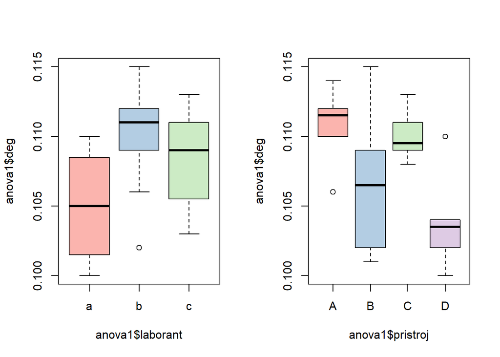

```r
par(mfrow = c(1, 2))
boxplot(anova1$deg~anova1$laborant, col = brewer.pal(3, 'Pastel1'))
boxplot(anova1$deg~anova1$pristroj, col = brewer.pal(4, 'Pastel1'))
```

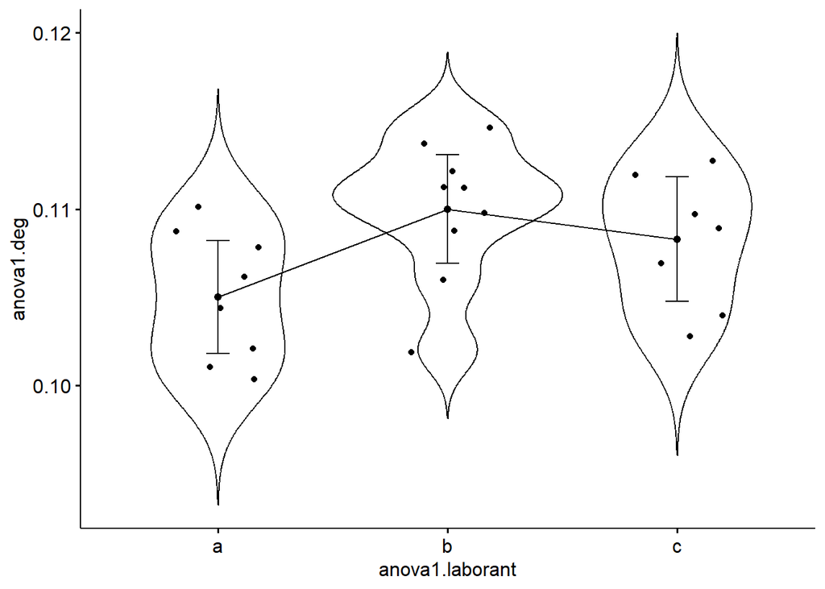

```r
pomoc1 <- data.frame(anova1$laborant, anova1$deg)
ggline(pomoc1, x = 'anova1.laborant', y = 'anova1.deg',
       add = c('mean_ci', 'jitter', 'violin'))
```

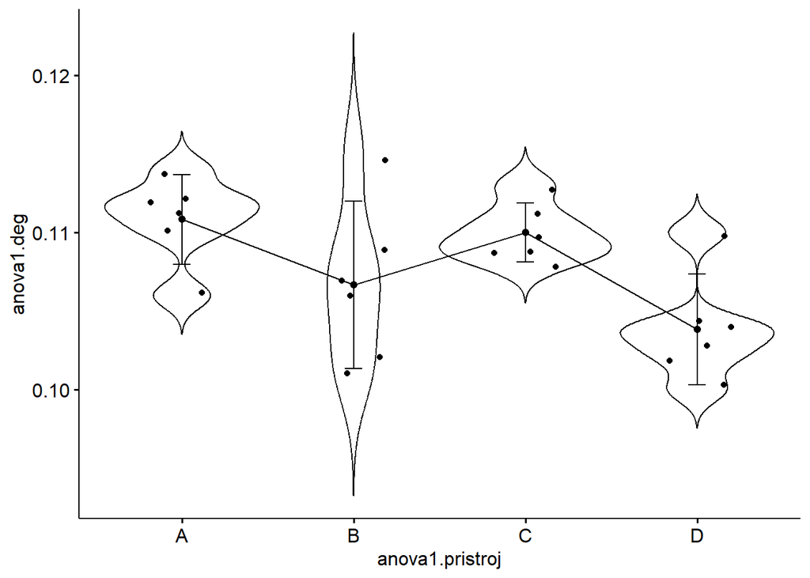

```r
pomoc2 <- data.frame(anova1$pristroj, anova1$deg)
ggline(pomoc2, x = 'anova1.pristroj', y = 'anova1.deg',
       add = c('mean_ci', 'jitter', 'violin'))
```

opat faktorizujeme

```r
laborant <- factor(anova1$laborant)
pristroj <- factor(anova1$pristroj)
an2 <- aov(anova1$deg~laborant + pristroj)
summary(an2)
```

```
##             Df    Sum Sq   Mean Sq F value  Pr(>F)
## laborant     2 0.0001079 5.395e-05   6.988 0.00568 **
## pristroj     3 0.0001785 5.948e-05   7.704 0.00162 **
## Residuals   18 0.0001390 7.720e-06
## ---
## Signif. codes:  0 '***' 0.001 '**' 0.01 '*' 0.05 '.' 0.1 ' ' 1
```

Obe P hodnoty < 0.05, zamietam hypotezu o nulovosti faktora laborant, laborant ma vplyv na merania. Zamietam tiez hypotezu o nulovosti faktora pristroj, pristroj ma vplyv na vysledky merania. Nasleduju post testy

```r
TukeyHSD(an2)
```

```
##   Tukey multiple comparisons of means
##     95% family-wise confidence level
##
## Fit: aov(formula = anova1$deg ~ laborant + pristroj)
##
## $laborant
##             diff           lwr         upr     p adj
## b-a  0.005000000  0.0015540923 0.008445908 0.0044097
## c-a  0.003285714 -0.0003845475 0.006955976 0.0839023
## c-b -0.001714286 -0.0052881261 0.001859555 0.4546955
##
## $pristroj
##             diff          lwr           upr     p adj
## B-A -0.003880952 -0.008415073  0.0006531685 0.1090105
## C-A -0.000547619 -0.005081740  0.0039865018 0.9858613
## D-A -0.006714286 -0.011248407 -0.0021801648 0.0028469
## C-B  0.003333333 -0.001200788  0.0078674542 0.1978815
## D-B -0.002833333 -0.007367454  0.0017007876 0.3208693
## D-C -0.006166667 -0.010700788 -0.0016325458 0.0059520
```

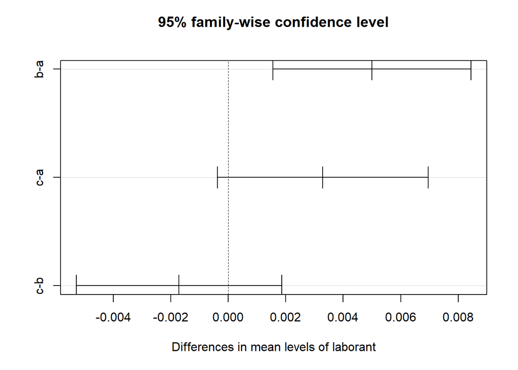

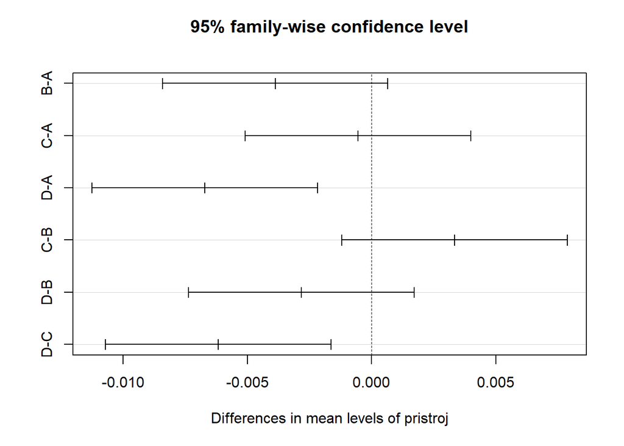

```r
plot(TukeyHSD(an2))
```

Odlisnosti su vyznamne pre laborantov a, b a pre pristroje A, D a C, D ANOVA s interakciami, pribudne hypoteza H0 ze kombinacie faktorov su nulove, nemaju vplyv na vysledky merania

```r
an3 <- aov(anova1$deg~laborant + pristroj + laborant * pristroj)
summary(an3)
```

```
##                   Df    Sum Sq   Mean Sq F value  Pr(>F)
## laborant           2 1.079e-04 5.395e-05   6.276 0.01364 *
## pristroj           3 1.785e-04 5.948e-05   6.919 0.00587 **
## laborant:pristroj  6 3.581e-05 5.970e-06   0.694 0.65932
## Residuals         12 1.032e-04 8.600e-06
## ---
## Signif. codes:  0 '***' 0.001 '**' 0.01 '*' 0.05 '.' 0.1 ' ' 1
```

P hodnota pre interakcie > 0.05, interakcie nemaju vplyv na vysledky merani, su nulove.

```r
TukeyHSD(an3)
```

```
##   Tukey multiple comparisons of means
##     95% family-wise confidence level
##
## Fit: aov(formula = anova1$deg ~ laborant + pristroj + laborant * pristroj)
##
## $laborant
##             diff           lwr         upr     p adj
## b-a  0.005000000  0.0011989733 0.008801027 0.0111083
## c-a  0.003285714 -0.0007627874 0.007334216 0.1181873
## c-b -0.001714286 -0.0056564292 0.002227858 0.4977165
##
## $pristroj
##             diff          lwr          upr     p adj
## B-A -0.003880952 -0.008906856  0.001144952 0.1543483
## C-A -0.000547619 -0.005573523  0.004478285 0.9877114
## D-A -0.006714286 -0.011740190 -0.001688382 0.0087604
## C-B  0.003333333 -0.001692571  0.008359237 0.2522543
## D-B -0.002833333 -0.007859237  0.002192571 0.3778484
## D-C -0.006166667 -0.011192571 -0.001140763 0.0154122
##
## $`laborant:pristroj`
##                  diff          lwr           upr     p adj
## b:A-a:A  4.333333e-03 -0.006293305  0.0149599718 0.8727581
## c:A-a:A  4.000000e-03 -0.010257132  0.0182571316 0.9873997
## a:B-a:A -6.500000e-03 -0.018140899  0.0051408992 0.5666208
## b:B-a:A  2.500000e-03 -0.009140899  0.0141408992 0.9985002
## c:B-a:A -6.938894e-17 -0.011640899  0.0116408992 1.0000000
## a:C-a:A  5.000000e-04 -0.011140899  0.0121408992 1.0000000
## b:C-a:A  2.000000e-03 -0.009640899  0.0136408992 0.9997972
## c:C-a:A  3.500000e-03 -0.008140899  0.0151408992 0.9793891
## a:D-a:A -6.000000e-03 -0.017640899  0.0056408992 0.6619418
## b:D-a:A -2.000000e-03 -0.013640899  0.0096408992 0.9997972
## c:D-a:A -4.500000e-03 -0.016140899  0.0071408992 0.9033988
## c:A-b:A -3.333333e-04 -0.013775086  0.0131084193 1.0000000
## a:B-b:A -1.083333e-02 -0.021459972 -0.0002066948 0.0442639
## b:B-b:A -1.833333e-03 -0.012459972  0.0087933052 0.9997892
## c:B-b:A -4.333333e-03 -0.014959972  0.0062933052 0.8727581
## a:C-b:A -3.833333e-03 -0.014459972  0.0067933052 0.9342779
## b:C-b:A -2.333333e-03 -0.012959972  0.0082933052 0.9981885
## c:C-b:A -8.333333e-04 -0.011459972  0.0097933052 0.9999999
```

[output cut: 33 more lines]

```
## b:C-a:C  1.500000e-03 -0.010140899  0.0131408992 0.9999875
## c:C-a:C  3.000000e-03 -0.008640899  0.0146408992 0.9933516
## a:D-a:C -6.500000e-03 -0.018140899  0.0051408992 0.5666208
## b:D-a:C -2.500000e-03 -0.014140899  0.0091408992 0.9985002
## c:D-a:C -5.000000e-03 -0.016640899  0.0066408992 0.8367452
## c:C-b:C  1.500000e-03 -0.010140899  0.0131408992 0.9999875
## a:D-b:C -8.000000e-03 -0.019640899  0.0036408992 0.3143756
## b:D-b:C -4.000000e-03 -0.015640899  0.0076408992 0.9507861
## c:D-b:C -6.500000e-03 -0.018140899  0.0051408992 0.5666208
## a:D-c:C -9.500000e-03 -0.021140899  0.0021408992 0.1538030
## b:D-c:C -5.500000e-03 -0.017140899  0.0061408992 0.7542479
## c:D-c:C -8.000000e-03 -0.019640899  0.0036408992 0.3143756
## b:D-a:D  4.000000e-03 -0.007640899  0.0156408992 0.9507861
## c:D-a:D  1.500000e-03 -0.010140899  0.0131408992 0.9999875
## c:D-b:D -2.500000e-03 -0.014140899  0.0091408992 0.9985002
```

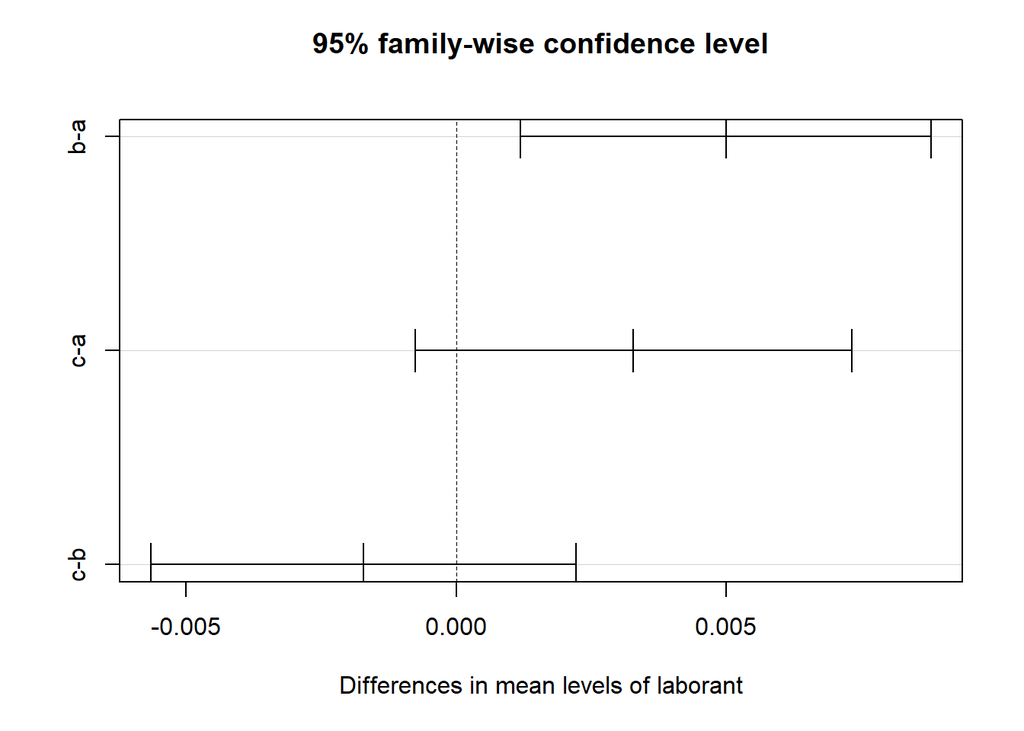

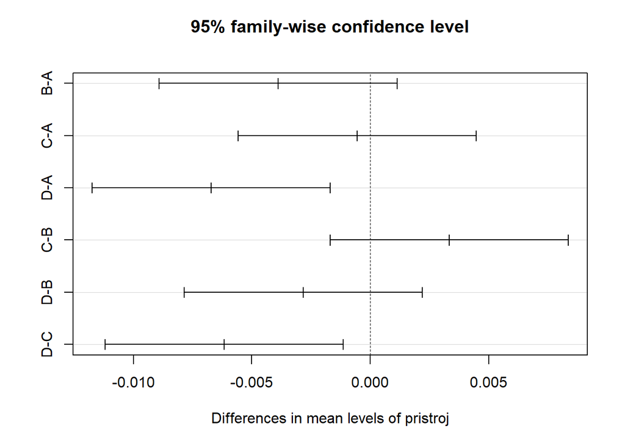

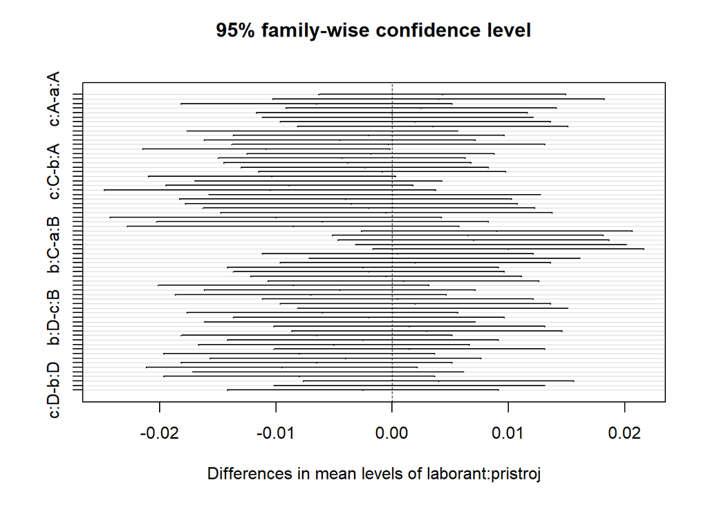

```r
plot(TukeyHSD(an3))
```